# psData: Political Science Panel-Series Data (v2)

Christopher Gandrud

csv,conf: 15 July 2014

# Talk Aims

- **Describe** political science/panel-series data problems.
- **Introduce** `psData`, our first attempt at a solution.
- **Thoughts** for future framework.
- **Get ideas** for going forward/avoiding effort duplication.

# What is panel-series data?

| Country | Year | Var1 | Var2 | Var3 | Var4 | Var5 | Var6 | Var7 | Var8 |
| --- | --- | --- | --- | --- | --- | --- | --- | --- | --- |
| Angola | 2000 |  |  |  |  |  |  |  |  |
| Angola | 2001 |  |  |  |  |  |  |  |  |
| Brazil | 2000 |  |  |  |  |  |  |  |  |
| Brazil | 2001 |  |  |  |  |  |  |  |  |
| Cambodia | 2000 |  |  |  |  |  |  |  |  |
| Cambodia | 2001 |  |  |  |  |  |  |  |  |

# Good

Many political scientists are creating/making publicly available panel-series data sets!

- [Database of Political Institutions](http://econ.worldbank.org/WBSITE/EXTERNAL/EXTDEC/EXTRESEARCH/0,,contentMDK:20649465~pagePK:64214825~piPK:64214943~theSitePK:469382,00.html)
- [Polity](http://www.systemicpeace.org/polity/polity4.htm)
- [Reinhart and Rogoff banking crisis varieties](http://www.carmenreinhart.com/data/browse-by-topic/topics/7/)

# Issues (1)

- Data **tied to particular studies**.
- Data **posted and maintained haphzardly**.

# Issues (2)

- **Variety of formats** (SPSS, Stata, Excel, CSV).
  - Excel data is often a **mess**.
- **Variety of panel/series identifiers**, even for regularly used panels (especially countries).
- Some **variables** are suggested by the literature (e.g. *winset*) are composed of other variables, but **aren’t regularly updated**.

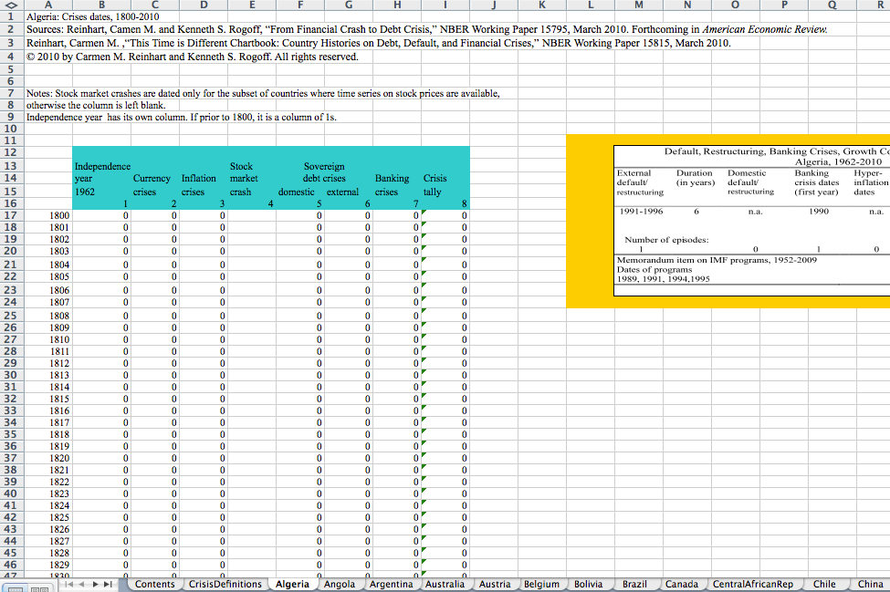

# Consequences

- **Effort Duplication**: Political scientists (or RA’s) **waste a lot** of time *downloading/cleaning/transforming/merging* commonly used data sets.
- **Errors introduced** by data import and transformation scripts that are written individually and never shared across researchers
  - Don’t benefit from **code review**.

# Solution

R package [`psData`](https://github.com/rOpenGov/psData)

# Goals (1)

- **Avoid effort duplication**
  - Standardised functions to *download/clean/transform* political science/panel-series data sets.
  - **Easy to contribute** new functions.

# Goals (2)

- **Standardised output**
  - Makes it **easy to merge** multiple data sets with the same panel-series structure.

# Goals (3)

- **Viral/quick error fixes**
  - Updates and errors are (inevitably) made they can be **found and corrected** by anyone.
  - Development hosted on **GitHub**
  - Corrections **automatically** propagated via **CRAN**.

# Master Build: Version 0.1.2

- Master build on [CRAN](http://cran.r-project.org/web/packages/psData/index.html)
- Silos each data set into its own *getter* or *creator* function.
  - `DpiGet`
  - `PolityGet`
  - `RRCrisisGet`
  - `WinsetCreator`
- *Creator* functions source *getter* functions for raw data.

# Examples (getter)

```r
# Load package
library(psData)

# Download/transform polity2 variable
PolityData <- PolityGet(vars = "polity2")

head(PolityData)
```

```
##  iso2c     country year polity2
##    AF Afghanistan 1800      -6
##    AF Afghanistan 1801      -6
##    AF Afghanistan 1802      -6
##    AF Afghanistan 1803      -6
##    AF Afghanistan 1804      -6
##    AF Afghanistan 1805      -6
```

# Examples (getter)

```r
# Download/transform Reinhart and Rogoff (2010)
RRData <- RRCrisisGet()

head(RRData)[1:5]
```

```
##  iso2c country year RR_Independence RR_CurrencyCrisis
##    AO  Angola 1800               0                 0
##    AO  Angola 1801               0                 0
##    AO  Angola 1802               0                 0
##    AO  Angola 1803               0                 0
##    AO  Angola 1804               0                 0
##    AO  Angola 1805               0                 0
```

# Example (creator)

```r
# Create winset and selector variables
WinsetData <- WinsetCreator()

head(WinsetData)
```

```
##  iso2c     country year    W ModS
##    AF Afghanistan 1975 0.25    0
##    AF Afghanistan 1976 0.25    0
##    AF Afghanistan 1977 0.25    0
##    AF Afghanistan 1989 0.50    0
##    AF Afghanistan 1990 0.50    0
##    AF Afghanistan 1991 0.50    0
```

# Dev builds

- **Development** at [rOpenGov](http://ropengov.github.io/).
- Ideas we are playing with:
  - Creating an [S4 R method](http://adv-r.had.co.nz/S4.html) for handling the downloaded data in a standard format.
  - [Homebrew](http://brew.sh/)-style **recipies**, specifying how to download the data and including meta-data (e.g. BibTex citations).
  - **Improve testing** (e.g. testdat).
  - Integration with data **version tracking** (minimum SHA hashes, maybe [dat](http://dat-data.com/)).

# Audience

Ideas for avoiding effort duplication with others building open data frameworks?

# Contact

Twitter: @chrisgandrud

GitHub: rOpenGov/psData